# ConRR R Markdown Template

2025-10-18

[figure not shown]

# Main Heading

This template should help you with the basics of R Markdown: text, code “chunks”, in-line code, plots and tables. It is easy to make lists, for example

- Make a list
- Check it twice
- Find out who’s naughty and nice
- Come to town

Here is some text: just type the same way as you would type in Word. Directly below this text, there is a code “chunk”, where you can type R code:

```r
# This is a chunk: your R code goes in here just like a regular R script:
scores <- c(5, 3, 6, 8, 10)
m <- mean(scores)
m
```

```
## [1] 6.4
```

```r
pacman::p_load(rio, here, ggplot)
films <- import(here('1_data/films.csv'))

head(films)
```

```
##   V1    tconst averageRating numVotes titleType              primaryTitle
## 1  1 tt0252994           8.0       16     short   Climbing Jacob's Ladder
## 2  2 tt2369678           6.0        9   tvMovie In Sickness and in Health
## 3  3 tt0069282           6.2     1023     movie                   Slither
## 4  4 tt1861338           8.2        8     short       God Bless the Child
## 5  5 tt0821815           6.6       16   tvMovie              Westward Ho!
## 6  6 tt0047180           7.7      424     movie                  Liliomfi
##               originalTitle startYear endYear runtimeMinutes
## 1   Climbing Jacob's Ladder      1899     \\N            \\N
## 2 In Sickness and in Health      2012     \\N             88
## 3                   Slither      1973     \\N             97
## 4       God Bless the Child      2011     \\N              3
## 5              Westward Ho!      1988     \\N             55
## 6                  Liliomfi      1955     \\N            109
##                       genres
## 1          Documentary,Short
## 2                     Family
## 3      Comedy,Crime,Thriller
## 4               Comedy,Short
## 5 Adventure,Animation,Comedy
## 6                     Comedy
```

```r
ave.vot<- ggplot(data = films, mapping = aes(x = averageRating, y = numVotes))+
  geom_point()+
  labs(title = 'Relationship between the number of votes and average rate of the films',
       x = 'Average Rating',
       y = 'Number of votes',
       caption = 'Source: Films data set')
```

## Sub-heading: chunk options

By default, knitr will show both your code and the output in the resulting document. You can use chunk options to change this behaviour. They work like R command arguments. First, tell knitr to not show the code, by using `echo=FALSE`:

```
## [1] 6.4
```

the average score of the students is 6.4. the total number of students who did their finals were 5

Second, tell knitr to not show the output, using `results='hide`:

```r
scores <- c(5, 3, 6, 8, 10)
the.mean <- mean(scores)
the.mean
```

You can also tell knitr to not run the code at all, using `eval=FALSE`:

```r
scores10 <- c(5, 3, 6, 8, 10, 3, 6, 12, 4, 9)
mean(scores10)
```

Instead of setting these options in every chunk, you can set options at the beginning that will then be in place for every chunk. We call this a “global” chunk option, and we do this in the very first chunk in this document where we set `echo=TRUE` using the line `knitr::opts_chunk$set(echo = TRUE)`.

A useful aspect of R Markdown is that, in the text, you can use objects that you’ve created inside the chunks. For example, the mean of `scores` is 6.4. You can even run little bits of code inside the text: the sum of the five scores is 32, for example.

## Sub-heading: plots

You can run code that creates plots, and knitr will show them by default:

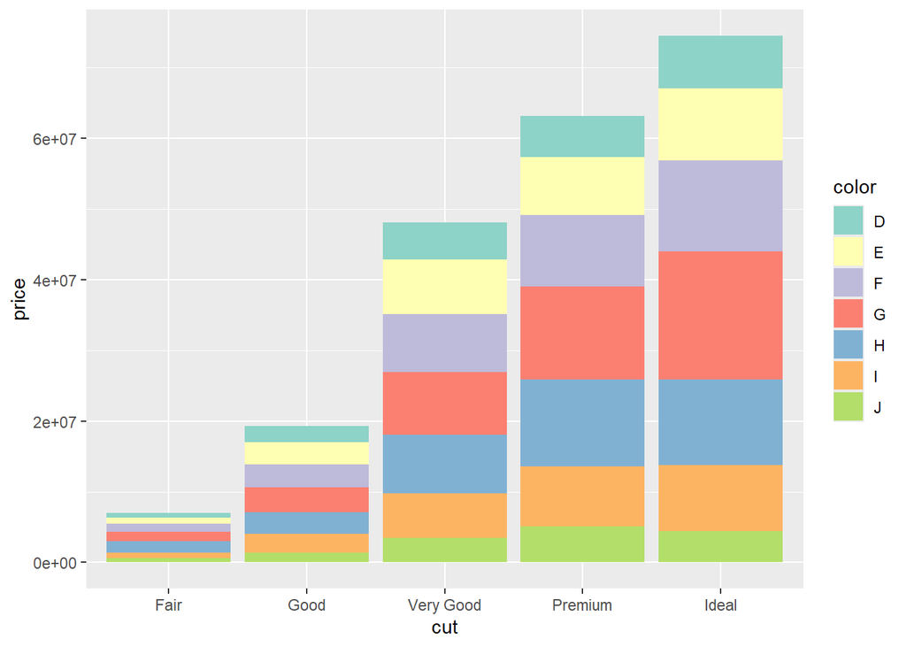

```r
myplot <- ggplot(data=diamonds, aes(x=cut, y=price, fill=color)) +
  geom_bar(stat="identity")+
  scale_fill_brewer(palette="Set3")
myplot
```

### Sub-sub-heading: chunk options for plots

There are also chunk options that let you alter your plot, such as specifying the dimensions:

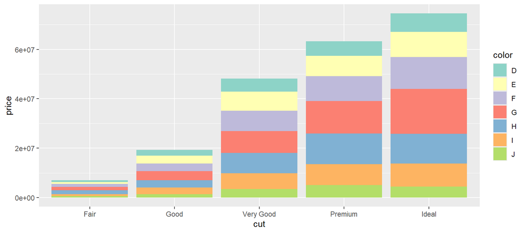